# bi594_HW1

Rebecca Decamp, Melissa Zarate and Christian Gagnon

2/14/2019

# Team SMGAL ITS analysis

# Almost entirely based on DADA2 Pipeline 1.8 Walkthrough:

# https://benjjneb.github.io/dada2/tutorial.html

# with edits by Carly D. Kenkel and modifications for my data by Christian Gagnon, Melissa Zarate and Rebecca Decamp

# 2/14/19

# R Version 3.5.2

# RStudio Version 1.1.463

# dada2 Version 1.10.1

# Phyloseq Version 1.26

# ggplots2 Version 3.1.0

# Rmisc Version 1.5

#### Introduction

# Marine fungi are not well studied at all, let alone coral-associated fungi, but metabarcoding analyses have shown that some sort of relationship between the two exist. In those analyses, such as wegley et al., most coral associated fungi taxa seem to overlap with terrestrial taxa.Bacterial symbionts known to have heterotrophic relationships with coral. Despite our lack of knowledge about fungal relationships with coral, we know fungi are present in coral.Amend et al. found taxa belonging to parasitic clade in transcriptome analysis.Wegley et al. found fungal genes involved in nitrate/nitrite ammonification, suggesting that they convert nitrogen for algal symbionts. Differences in inshore and offshore bacteria communities in coral has been widely studied. McCliment et al., 2012 (16S):found more bacterial communities/ more OTUs inshore.On the other hand, other studies (Pantos et al) have found less diversity overall inshore. In our study we looked ant fungal communities in 3 location around the islands of Moorea and Tahiti which at both inshore and offshore sites.

# We hypothesized that there would be more diversity in fungal communities in offshore coral reef populations primarily due to the reduced amount of UV exposure since fungi grow best in low light environments. But also, because of deeper waters have less disturbance, and less extreme conditions (such as temperature variation).

# <sub>########################</sub>

##### PRE-PROCESSING

# <sub>########################</sub>

# fastq files should have R1 & R2 designations for PE reads

# Also - some pre-trimming. Retain only PE reads that match amplicon primer. Remove reads containing Illumina sequencing adapters

# in Terminal home directory:

# following instructions of installing BBtools from https://jgi.doe.gov/data-and-tools/bbtools/bb-tools-user-guide/installation-guide/

# 1. download BBMap package, sftp to installation directory

# 2. untar:

# tar -xvzf BBMap_(version).tar.gz

# 3. test package:

# cd bbmap

# ~/bin/bbmap/stats.sh in=~/bin/bbmap/resources/phix174_ill.ref.fa.gz

# my adaptors, which I saved as “adaptors.fasta”

# >forward

# AATGATACGGCGACCAC

# >forwardrc

# GTGGTCGCCGTATCATT

# >reverse

# CAAGCAGAAGACGGCATAC

# >reverserc

# GTATGCCGTCTTCTGCTTG

# primers for ITS:

# >forward

# GTGAATTGCAGAACTCCGTG

# >reverse

# CCTCCGCTTACTTATATGCTT

# Still in terminal

# ls *R1_001.fastq | cut -d ’*’ -f 1 > samples.list #for file in $(cat samples.list); do mv ${file}**R1*.fastq ${file}*R1.fastq; mv ${file}**R2*.fastq ${file}_R2.fastq; done #for file in $(cat samples.list); do ~/bin/bbmap/bbduk.sh in1=${file}_R1.fastq in2=${file}_R2.fastq ref=adaptors.fasta k=12 out1=${file}_R1_NoIll.fastq out2=${file}_R2_NoIll.fastq; done &>bbduk_NoIll.log #for file in $(cat samples.list); do ~/bin/bbmap/bbduk.sh in1=${file}_R1_NoIll.fastq in2=${file}_R2_NoIll.fastq ftl=4 out1=${file}_R1_NoIll_No4N.fastq out2=${file}_R2_NoIll_No4N.fastq; done &>bbduk_No4N.log #for file in $(cat samples.list); do ~/bin/bbmap/bbduk.sh in1=${file}_R1_NoIll_No4N.fastq in2=${file}_R2_NoIll_No4N.fastq restrictleft=21 k=10 literal=GTGAATTGCAGAACTCCGTG,CCTCCGCTTACTTATATGCTT outm1=${file}_R1_NoIll_NoITS.fastq outu1=${file}_R1_check.fastq outm2=${file}_R2_NoIll_NoITS.fastq outu2=${file}_R2_check.fastq; done &>bbduk_NoITS.log

# renaming file names

# for longer file names:

# for file in *_NoITS.fastq # do export first6=${file:0:6} # echo ${first6} # cp $file ./renamed/${first6}.fastq # done # # for shorter file names: # for file in *_NoITS.fastq # do export first5=${file:0:5} # echo ${first5} # cp $file ./renamed/${first5}.fastq # done

# did sftp of *_NoITS.fastq files to the folder to be used in dada2

# <sub>########################</sub>

##### DADA2 BEGINS

# <sub>########################</sub>

# installing/loading packages:

```r
#if (!requireNamespace("BiocManager", quietly = TRUE))
#  install.packages("BiocManager")
#BiocManager::install("dada2", version = "3.8")
```

# Set Path and read-in data

```r
library(dada2); packageVersion("dada2")
```

```
## [1] '1.10.1'
```

```r
#I have version 1.10.1 - tutorial says 1.8 but I think that's OK, can't find a version 1.10 walkthrough

path <- "/Users/christiangagnon/Documents/BI594/rdecamp" # CHANGE ME to the directory containing the fastq files after unzipping.
fns <- list.files(path)
fns
```

```
##   [1] "051_R1.fastq"    "051_R1.fastq.gz" "051_R2.fastq"
##   [4] "051_R2.fastq.gz" "055_R1.fastq"    "055_R1.fastq.gz"
##   [7] "055_R2.fastq"    "055_R2.fastq.gz" "058_R1.fastq"
##  [10] "058_R1.fastq.gz" "058_R2.fastq"    "058_R2.fastq.gz"
##  [13] "062_R1.fastq"    "062_R1.fastq.gz" "062_R2.fastq"
##  [16] "062_R2.fastq.gz" "063_R1.fastq"    "063_R1.fastq.gz"
##  [19] "063_R2.fastq"    "063_R2.fastq.gz" "065_R1.fastq"
##  [22] "065_R1.fastq.gz" "065_R2.fastq"    "065_R2.fastq.gz"
##  [25] "070_R1.fastq"    "070_R1.fastq.gz" "070_R2.fastq"
##  [28] "070_R2.fastq.gz" "072_R1.fastq"    "072_R1.fastq.gz"
##  [31] "072_R2.fastq"    "072_R2.fastq.gz" "073_R1.fastq"
##  [34] "073_R1.fastq.gz" "073_R2.fastq"    "073_R2.fastq.gz"
##  [37] "076_R1.fastq"    "076_R1.fastq.gz" "076_R2.fastq"
##  [40] "076_R2.fastq.gz" "087_R1.fastq"    "087_R1.fastq.gz"
##  [43] "087_R2.fastq"    "087_R2.fastq.gz" "089_R1.fastq"
```

[output cut: 114 more lines]

```r
fastqs <- fns[grepl(".fastq$", fns)]
fastqs <- sort(fastqs) # Sort ensures forward/reverse reads are in same order
fnFs <- fastqs[grepl("_R1", fastqs)] # Just the forward read files
fnRs <- fastqs[grepl("_R2", fastqs)] # Just the reverse read files

# Get sample names, assuming files named as so: SAMPLENAME_XXX.fastq; OTHERWISE MODIFY
sample.names <- sapply(strsplit(fnFs, "_"), `[`, 1) #the last number will select the field for renaming
# Specify the full path to the fnFs and fnRs
fnFs <- file.path(path, fnFs)
fnRs <- file.path(path, fnRs)
```

###### Visualizing raw data

# Used quality profile to decide to trim at 200 bp

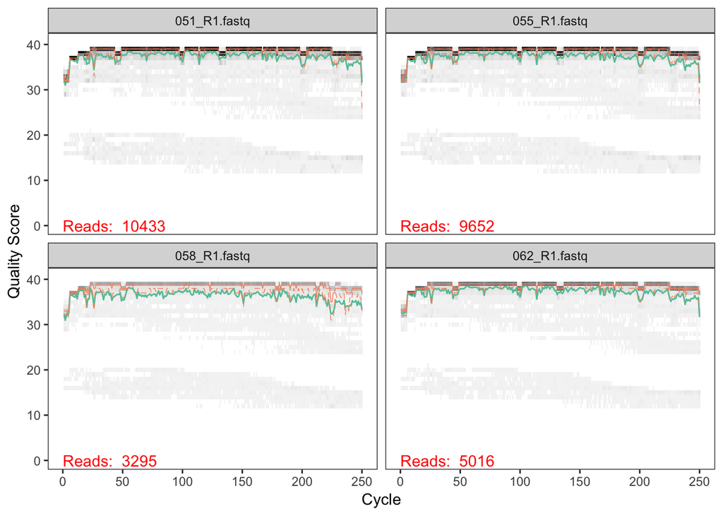

```r
#First, lets look at quality profile of R1 reads

plotQualityProfile(fnFs[c(1,2,3,4)])
```

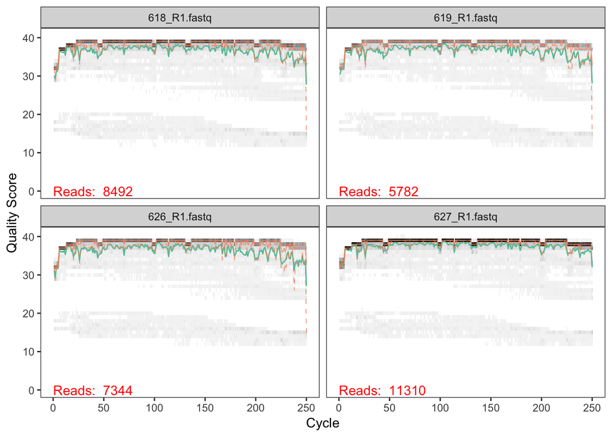

```r
plotQualityProfile(fnFs[c(90,91,92,93)])
```

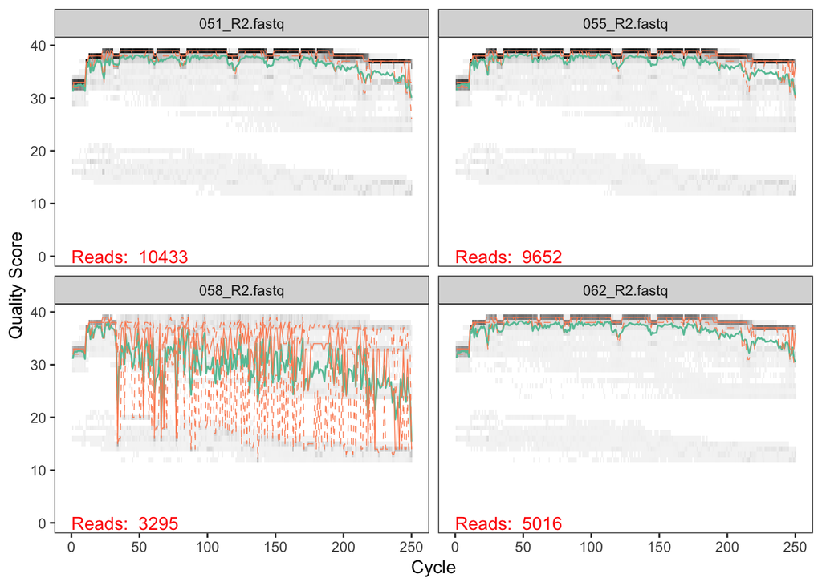

```r
#Then look at quality profile of R2 reads

plotQualityProfile(fnRs[c(1,2,3,4)])
```

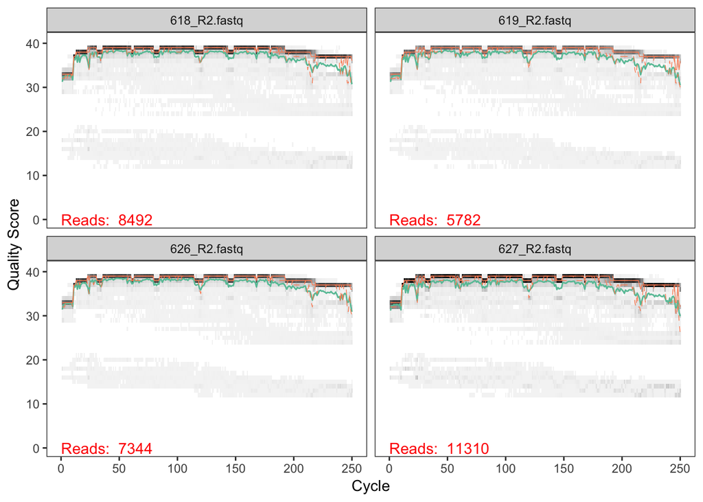

```r
plotQualityProfile(fnRs[c(90,91,92,93)])
```

```r
#starts to drop off around 200 bp, will make that the cutoff values for filter&trim below
```